# Notebook

#### Tuning and Parameter Selection

We've performed extensive tuning to select the optimal model settings and configurations. In addition to selecting optimal:

- Learning rate
- Batch size (larger batch sizes can converge faster in terms of epochs because they process more data at once, but they often generalize less effectively compared to smaller batches)
- Number of frozen epochs
- Optimal learning rate scheduler and parameters
- Weight decay

Various different augmentation techniques were also evaluated. We've tested the model with these specific fixed sets of augmentations and parameters (see the last table in the notebook for specific results). Augmentation would be applied to images randomly each time they are loaded into a batch:

- `None`
- `mult_2`
  - Intensity = 2.0 (increases the transformation's strength, potentially leading to feature distortion that might impair model generalization on natural images)
  - Horizontal and vertical flipping of images and rotation up to 25%
- `mult_1.25_more_trans`
  - Additionally to all from previous:
    - Zooming between 0.75x and 1.8x
    - Perspective warping (p_affine)
    - Random erasing of parts of the image
- `mult_2.0_more_trans`
  - Same as above with intensity = 2.0

##### Top 10 best performing configurations

We can see that all the best performing configurations were using the `mult_1.25_more_trans` augmentation set. The best performing configurations with other sets were:

|  | value | aug_mode | base_lr | batch_size | freeze_epochs | lr_mult | lr_scheduler | pct_start | weight_decay | duration(s) |
| --- | --- | --- | --- | --- | --- | --- | --- | --- | --- | --- |
| 84 | 0.96488 | mult_1.25_more_trans | 0.00141 | 64 | 6 | 10 | flat_cos | 0.39955 | 0.09308 | 489.47 |
| 63 | 0.96351 | mult_1.25_more_trans | 0.00147 | 64 | 6 | 10 | flat_cos | 0.40067 | 0.07373 | 489.25 |
| 66 | 0.96269 | mult_1.25_more_trans | 0.00149 | 64 | 6 | 10 | flat_cos | 0.44996 | 0.05393 | 489.66 |
| 53 | 0.96267 | mult_1.25_more_trans | 0.00110 | 64 | 5 | 10 | flat_cos | 0.34547 | 0.05261 | 474.92 |
| 41 | 0.96264 | mult_1.25_more_trans | 0.00115 | 64 | 6 | 10 | flat_cos | 0.38499 | 0.06020 | 488.18 |
| 100 | 0.96263 | mult_1.25_more_trans | 0.00158 | 64 | 5 | 10 | flat_cos | 0.60906 | 0.05988 | 476.59 |
| 122 | 0.96118 | mult_1.25_more_trans | 0.00122 | 64 | 5 | 50 | flat_cos | 0.42098 | 0.06611 | 473.80 |
| 110 | 0.96116 | mult_1.25_more_trans | 0.00123 | 64 | 5 | 50 | flat_cos | 0.41988 | 0.05290 | 474.35 |
| 80 | 0.95976 | mult_1.25_more_trans | 0.00148 | 64 | 5 | 10 | flat_cos | 0.47579 | 0.06992 | 475.82 |
| 114 | 0.95974 | mult_1.25_more_trans | 0.00105 | 64 | 5 | 50 | flat_cos | 0.42363 | 0.08556 | 475.84 |

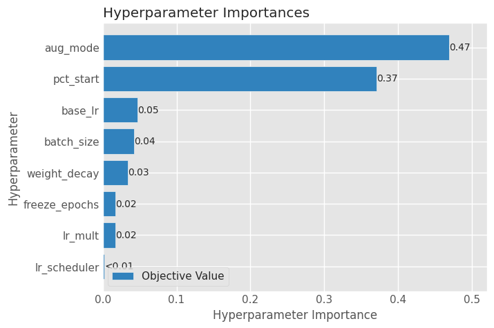

#### Learning rate:

We've used in the `lr_finder` implemented in FastAI (LR Range test) to select the tuning ranges for the base_lr rate

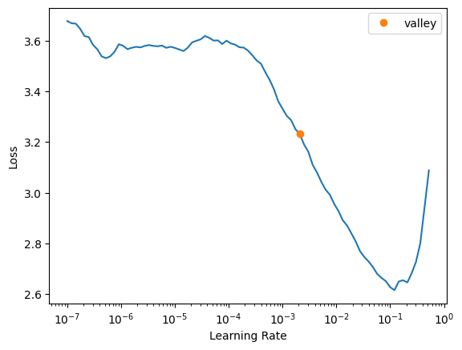

Based on our tuning results we found that the optimal `base_lr` is around `~0.0015 +- 0.0005`

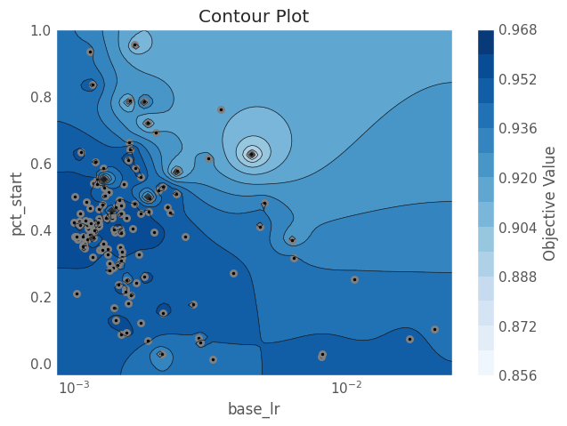

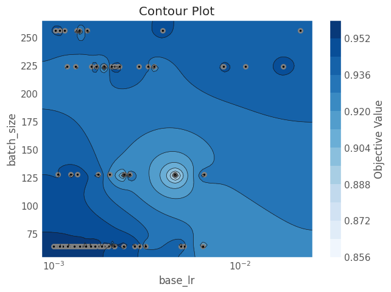

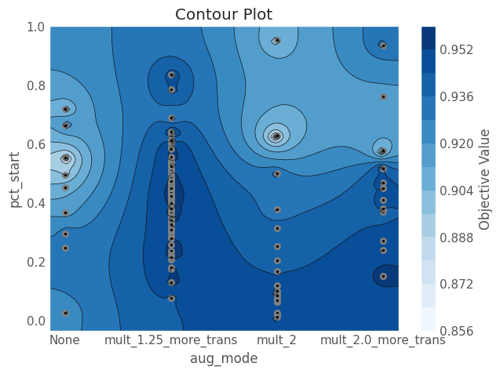

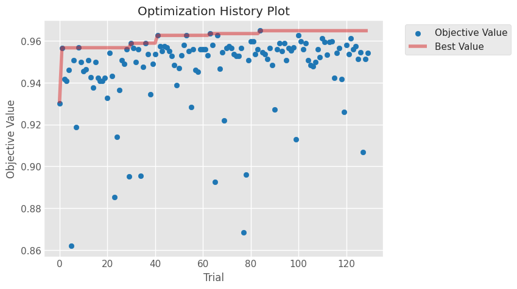

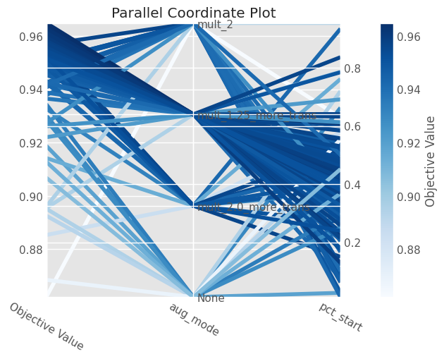

[output not shown]

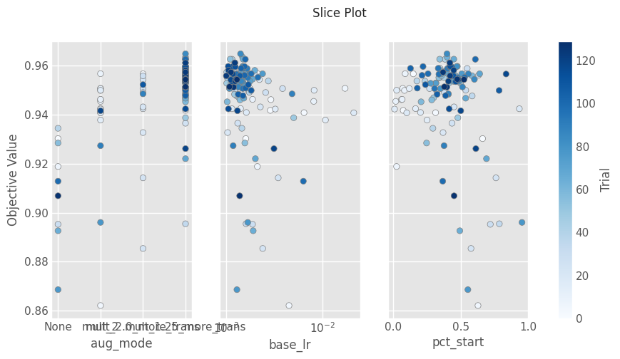

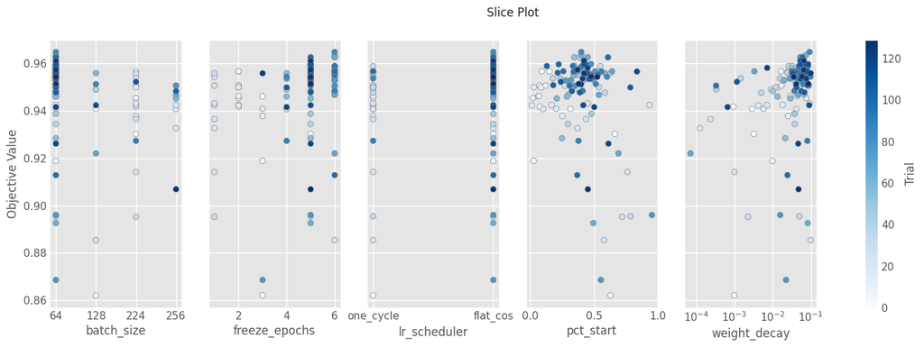

### Full Tuning Results

The table below shows the results from all the trials:

|  | value | aug_mode | base_lr | batch_size | freeze_epochs | lr_mult | lr_scheduler | pct_start | weight_decay | duration(s) |
| --- | --- | --- | --- | --- | --- | --- | --- | --- | --- | --- |
| 84 | 0.965 | mult_1.25_more_trans | 0.001 | 64 | 6 | 10 | flat_cos | 0.400 | 0.093 | 489.47 |
| 63 | 0.964 | mult_1.25_more_trans | 0.001 | 64 | 6 | 10 | flat_cos | 0.401 | 0.074 | 489.25 |
| 66 | 0.963 | mult_1.25_more_trans | 0.001 | 64 | 6 | 10 | flat_cos | 0.450 | 0.054 | 489.66 |
| 53 | 0.963 | mult_1.25_more_trans | 0.001 | 64 | 5 | 10 | flat_cos | 0.345 | 0.053 | 474.92 |
| 41 | 0.963 | mult_1.25_more_trans | 0.001 | 64 | 6 | 10 | flat_cos | 0.385 | 0.060 | 488.18 |
| 100 | 0.963 | mult_1.25_more_trans | 0.002 | 64 | 5 | 10 | flat_cos | 0.609 | 0.060 | 476.59 |
| 122 | 0.961 | mult_1.25_more_trans | 0.001 | 64 | 5 | 50 | flat_cos | 0.421 | 0.066 | 473.80 |
| 110 | 0.961 | mult_1.25_more_trans | 0.001 | 64 | 5 | 50 | flat_cos | 0.420 | 0.053 | 474.35 |
| 80 | 0.960 | mult_1.25_more_trans | 0.001 | 64 | 5 | 10 | flat_cos | 0.476 | 0.070 | 475.82 |
| 114 | 0.960 | mult_1.25_more_trans | 0.001 | 64 | 5 | 50 | flat_cos | 0.424 | 0.086 | 475.84 |
| 81 | 0.960 | mult_1.25_more_trans | 0.001 | 64 | 5 | 10 | flat_cos | 0.471 | 0.071 | 476.12 |
| 101 | 0.960 | mult_1.25_more_trans | 0.002 | 64 | 5 | 10 | flat_cos | 0.222 | 0.056 | 475.48 |
| 111 | 0.960 | mult_1.25_more_trans | 0.001 | 64 | 5 | 50 | flat_cos | 0.418 | 0.054 | 474.98 |
| 113 | 0.960 | mult_1.25_more_trans | 0.001 | 64 | 5 | 50 | flat_cos | 0.434 | 0.075 | 475.70 |
| 94 | 0.959 | mult_1.25_more_trans | 0.001 | 64 | 6 | 10 | flat_cos | 0.335 | 0.055 | 488.58 |
| 36 | 0.959 | mult_1.25_more_trans | 0.001 | 64 | 5 | 10 | flat_cos | 0.348 | 0.032 | 475.65 |
| 103 | 0.959 | mult_1.25_more_trans | 0.001 | 64 | 5 | 10 | flat_cos | 0.130 | 0.049 | 475.03 |
| 30 | 0.959 | mult_1.25_more_trans | 0.001 | 64 | 6 | 10 | one_cycle | 0.549 | 0.026 | 490.58 |
| 92 | 0.959 | mult_1.25_more_trans | 0.002 | 64 | 6 | 10 | flat_cos | 0.403 | 0.086 | 489.68 |
| 120 | 0.958 | mult_1.25_more_trans | 0.001 | 64 | 5 | 50 | flat_cos | 0.449 | 0.007 | 475.51 |
| 64 | 0.958 | mult_1.25_more_trans | 0.002 | 64 | 6 | 10 | flat_cos | 0.394 | 0.070 | 489.85 |
| 52 | 0.958 | mult_1.25_more_trans | 0.001 | 64 | 5 | 10 | flat_cos | 0.353 | 0.031 | 475.95 |
| 42 | 0.957 | mult_1.25_more_trans | 0.001 | 64 | 6 | 10 | flat_cos | 0.380 | 0.062 | 488.05 |
| 44 | 0.957 | mult_1.25_more_trans | 0.001 | 64 | 6 | 10 | flat_cos | 0.424 | 0.033 | 490.17 |
| 71 | 0.957 | mult_1.25_more_trans | 0.001 | 64 | 5 | 10 | flat_cos | 0.392 | 0.061 | 474.91 |
| 124 | 0.957 | mult_1.25_more_trans | 0.001 | 64 | 5 | 50 | flat_cos | 0.370 | 0.065 | 476.49 |
| 45 | 0.957 | mult_1.25_more_trans | 0.001 | 64 | 6 | 10 | flat_cos | 0.404 | 0.035 | 488.81 |
| 8 | 0.957 | mult_2 | 0.002 | 64 | 2 | 10 | one_cycle | 0.091 | 0.017 | 434.36 |
| 98 | 0.957 | mult_1.25_more_trans | 0.002 | 64 | 6 | 10 | one_cycle | 0.259 | 0.032 | 488.52 |
| 70 | 0.957 | mult_1.25_more_trans | 0.002 | 64 | 6 | 10 | flat_cos | 0.641 | 0.003 | 489.16 |

[output cut: 100 more lines]

[output not shown]